# Stat Final Part Two

Rachel Loh

3/17/2020

Warm-ups (10 points each)

1. Which is the only movie to have won all 5 of the awards in this dataset?

The only movie to have won all 5 of the awards in this dataset is Million Dollar Baby.

```r
oscars %>%
  select(movie, award) %>%
  count(movie) %>%
  arrange(desc(n))
```

```
## # A tibble: 336 x 2
##    movie                        n
##    <chr>                    <int>
##  1 Million Dollar Baby          5
##  2 Network                      4
##  3 West Side Story              4
##  4 A Streetcar Named Desire     3
##  5 Cabaret                      3
##  6 From Here to Eternity        3
##  7 Going My Way                 3
##  8 Gone with the Wind           3
##  9 It Happened One Night        3
## 10 Kramer vs. Kramer            3
## # … with 326 more rows
```

2. Of all actresses who have won the Best Actress award, what are the three most common first names?

The three most common names are Hilary, Katharine, and Elizabeth (tied with Helen and Jane).

```r
oscars %>%
  select(award, person) %>%
  filter(award%in% "Best Actress") %>%
  separate(person, c("First", " Last")) %>%
  group_by(First) %>%
  count(First) %>%
  arrange(desc(n))
```

```
## # A tibble: 63 x 2
## # Groups:   First [63]
##    First         n
##    <chr>     <int>
##  1 Hilary        4
##  2 Katharine     4
##  3 Elizabeth     3
##  4 Helen         3
##  5 Jane          3
##  6 Bette         2
##  7 Faye          2
##  8 Ginger        2
##  9 Glenda        2
## 10 Gwyneth       2
## # … with 53 more rows
```

3. What US State, or non-US country, has produced the most Oscar winners (for the awards in this dataset)?

```r
oscars %>%
  select(birthplace) %>%
  mutate(location = word(birthplace, -1)) %>%
  group_by(location) %>%
  count(location) %>%
  arrange(desc(n))
```

```
## # A tibble: 67 x 2
## # Groups:   location [67]
##    location     n
##    <chr>    <int>
##  1 England     58
##  2 Ca          45
##  3 City        36
##  4 Ny          29
##  5 Il          21
##  6 Ma          14
##  7 Mo          14
##  8 Nj          13
##  9 Pa          11
## 10 Ne          10
## # … with 57 more rows
```

Age and Gender (60 points)

The information in this dataset includes two awards given only to women (Best Actress, Best Supporting Actress) and two awards given only to men (Best Actor, Best Supporting Actor).

Create a linear model that explores how the typical age of acting award winners has changed over time, and how that effect is different for the two genders of awards.

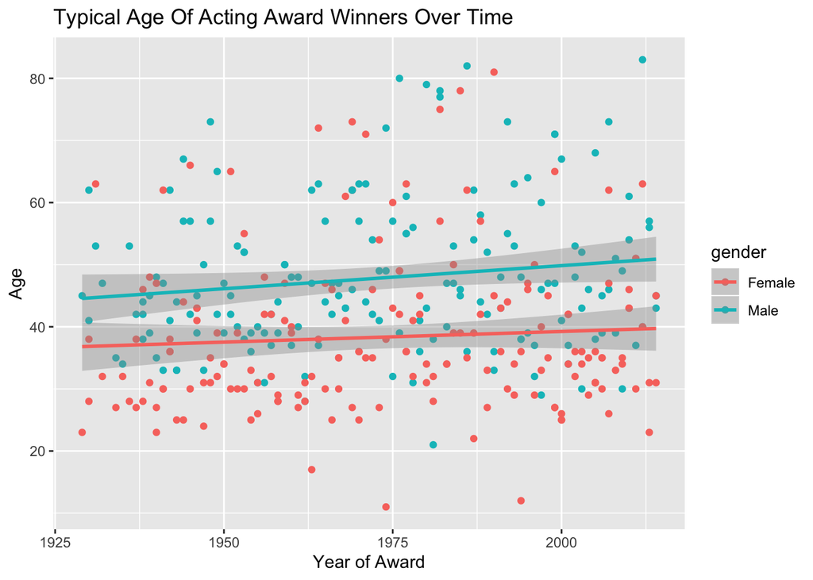

```r
fix_year <- function(year_birth) {
  year_birth <- as.numeric(year_birth)
  ifelse(year_birth < 1000, year_birth + 1900, year_birth + 0)
}

oscars %>%
  select(date_of_birth, year_of_award, award) %>%
  separate(date_of_birth, c("Day", "Month", "year_birth")) %>%
  mutate(year_birth = fix_year(year_birth),
         age = year_of_award - as.numeric(year_birth),
         gender = case_when(award == "Best Actress" ~ "Female",
            award == "Best Supporting Actress" ~ "Female",
            award == "Best Actor" ~ "Male",
            award == "Best Supporting Actor" ~ "Male")) %>%
  filter(award%in% c("Best Actress", "Best Supporting Actress", "Best Actor", "Best Supporting Actor")) %>%
  ggplot(aes(x = year_of_award, y = age, color = gender)) +
  geom_point() +
  stat_smooth(method = "lm") +
  ggtitle("Typical Age Of Acting Award Winners Over Time") + xlab("Year of Award") + ylab("Age")
```

Bootstrapping (60 points)

Use a bootstrap approach to answer the following question: What is an approximate 95% confidence interval for percent of “Big 5 Award” award winners who are not white?

In addition to the confidence interval, make a plot that illustrates your findings.

The 95% confidence interval for percent of “Big 5 Award” award winners who are not white is displayed below:

```r
booting <- oscars %>%
  select(race_ethnicity) %>%
  mutate(race_ethnicity = case_when(race_ethnicity == "White" ~ "White", race_ethnicity != "White" ~ "Non-White"))

white_or_not <- booting %>%
  bootstrap(100)

my_prop <- function(x,i){
sum(x[i] == "Non-White") / length(x)
}

white_or_not_boots <- white_or_not %>%
  mutate(boot_prop = map_dbl(strap, ~my_prop(data.frame(.x)$race_ethnicity)))

white_or_not_boots %>%
  pull(boot_prop) %>%
  quantile(c(0.025, 0.975))
```

```
##       2.5%      97.5%
## 0.04761905 0.08962585
```

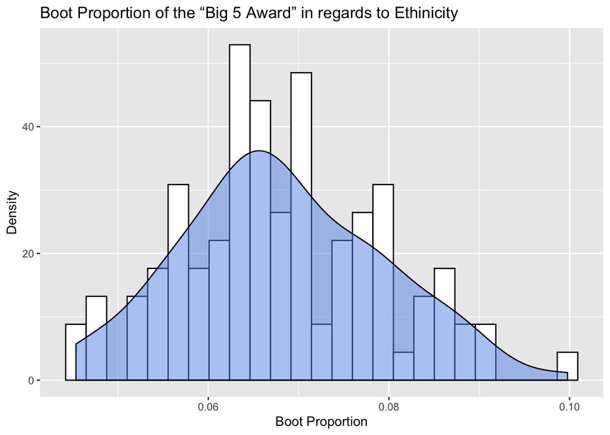

```r
ggplot(white_or_not_boots, aes(x = boot_prop)) +
  geom_histogram(aes(y = ..density..),
                 fill = "white",
                 color = "black",
                 bins = 25) +
  geom_density(fill = "cornflowerblue", alpha = 0.5) +
  ggtitle("Boot Proportion of the “Big 5 Award” in regards to Ethinicity") + xlab("Boot Proportion") + ylab("Density")
```

Extra Credit (10 points)

Make me the most interesting, beautiful, insightful plot that you possibly can with this data. I will award extra credit to standout visualizations that tell a compelling story in a clear way.

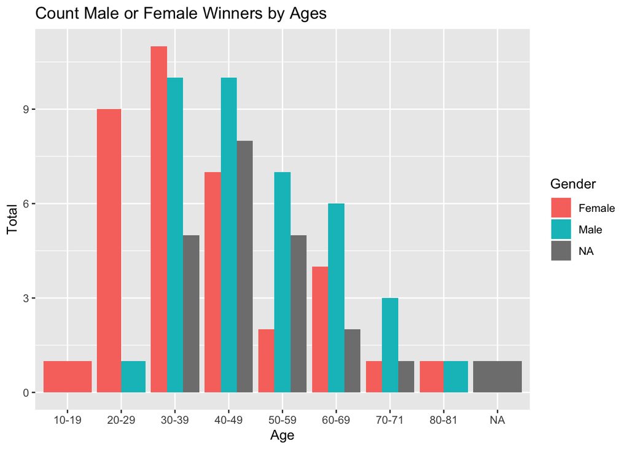

```r
oscars_graph <- oscars %>%
  separate(date_of_birth, c("Day", "Month", "year_birth")) %>%
  mutate(year_birth = fix_year(year_birth),
         age = year_of_award - as.numeric(year_birth),
         gender = case_when(award == "Best Actress" ~ "Female",
            award == "Best Supporting Actress" ~ "Female",
            award == "Best Actor" ~ "Male",
            award == "Best Supporting Actor" ~ "Male"),
         race_ethnicity = case_when(race_ethnicity == "White" ~ "White", race_ethnicity != "White" ~ "Non-White")) %>%
  count(age, gender) %>%
  mutate(age_chunk  = case_when(age >= 10 & age <= 19 ~ "10-19",
                           age >= 20 & age <= 29 ~ "20-29",
                           age >= 30 & age <= 39 ~ "30-39",
                           age >= 40 & age <= 49 ~ "40-49",
                           age >= 50 & age <= 59 ~ "50-59",
                           age >= 60 & age <= 69 ~ "60-69",
                           age >= 70 & age <= 79 ~ "70-71",
                           age >= 80 & age <= 89 ~ "80-81",
                           age >= 90 & age <= 99 ~ "90-91"))

oscars_graph %>%
  ggplot() + geom_col(data = oscars_graph, aes(x = age_chunk, y = n, fill = gender), position = "dodge") + ggtitle("Count Male or Female Winners by Ages") + xlab("Age") + ylab("Total") + scale_fill_discrete("Gender")
```